# 03.Example 3

Modified

Th 2024-09-12 08:16

## Given:

A long copper bar of rectangular cross section, whose width $w$ is much greater than its thickness $L$, is maintained in contact with a heat sink at its lower surface, and the temperature throughout the bar is approximately equal to that of the sink, $T_o$. Suddenly, an electric current is passed through the bar and a stream of air of temperature $T_{\infty}$ is passed over the top surface, while the bottom surface continues to be maintained at $T_o$.

Figure 1: Copper Bar

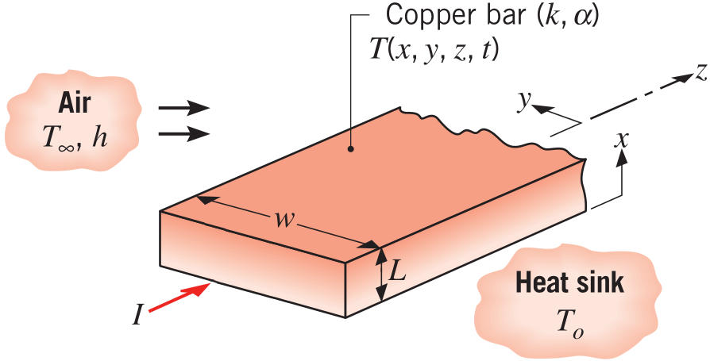

## Required:

Determine the boundary and initial conditions that are needed to solve this arrangement for the temperature distribution as a function of both position and time.

## Solution:

Some simplifying assumptions may be made to aid in the solution. The first assumption is the system is 1D in the thickness direction. The second assumption is that the material is isotropic. With these two assumptions, the system becomes

Figure 2: Simplified System

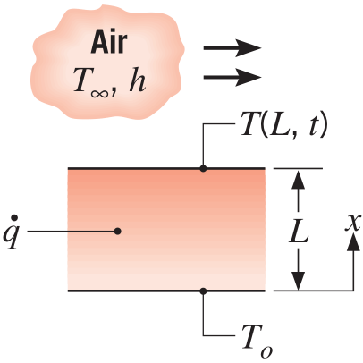

Beginning with the initial condition constraint, the specific language of the problem statement that indicates what the initial condition must be is in the statement

… is maintained in contact with a heat sink at its lower surface, and the temperature throughout the bar is approximately equal to that of the sink, $T_o$.

This statement is a clue as to what the initial condition is. The bar’s temperature at time equal to zero is going to be at the sink temperature. Thus the initial condition is

Answer: $T\left(x, t=0s\right)=T_o$

What this statement is indicating is that for all positions within the system the temperature is $T_o$ for when time is equal to zero seconds. The boundary conditions are found by first identifying what surfaces have something acting on them. Looking at the diagram, it may be seen that the bottom and top surface have something acting on them. Thus there will be two boundary condition. Starting with the bottom surface. The problem statement says

… the bottom surface continues to be maintained at $T_o$.

Thus the first boundary condition is then

Answer: $T\left(x=0m, t\right)=T_o$

This boundary condition is stating that the conduction term at $x=L$ is equal to the convection term at that location.